# Impact du COVID sur l’inflation en ce qui concerne les vêtements et chaussures (IPCH)

Soline Thomas, Romane Lequeux et Margot Philipe

17 décembre 2024

# Les données

## Chargement des données

```r
setwd("//home-ens.univ-ubs.fr/e2302017/Mes documents/SAE-303")
Ind_prix <- read_delim("Indices_prix_vetements_chaussures_oct24.csv", delim = ";", escape_double = FALSE, trim_ws = TRUE,show_col_types = FALSE)
```

## Visualisation des données

```r
str(Ind_prix)
```

```
## spc_tbl_ [346 × 2] (S3: spec_tbl_df/tbl_df/tbl/data.frame)
##  $ Date  : chr [1:346] "1996-01" "1996-02" "1996-03" "1996-04" ...
##  $ Valeur: num [1:346] 89.4 90.7 93.8 93.9 93.8 93.4 90.4 91.9 94 94.1 ...
##  - attr(*, "spec")=
##   .. cols(
##   ..   Date = col_character(),
##   ..   Valeur = col_double()
##   .. )
##  - attr(*, "problems")=<externalptr>
```

```r
summary(Ind_prix)
```

```
##      Date               Valeur
##  Length:346         Min.   : 86.96
##  Class :character   1st Qu.: 93.61
##  Mode  :character   Median : 96.67
##                     Mean   : 97.59
##                     3rd Qu.:103.04
##                     Max.   :109.30
```

# Série Temporelle

```r
# création de la série temporelle
Ind_prix.ts = ts(Ind_prix$Valeur, start = c(1996, 01), frequency = 12)
```

## Visualisation des données (tableau de buys ballot)

```r
buysbal(Ind_prix.ts , y=NULL, frequency=12, units="years", datemin=NULL,
        dateformat="%Y-%m", count=FALSE)
```

```
##          1      2      3      4      5      6      7      8      9     10
## 1996 89.40  90.70  93.80  93.90  93.80  93.40  90.40  91.90  94.00  94.10
## 1997 89.30  92.40  94.10  94.20  94.00  93.80  90.20  92.50  94.40  94.40
## 1998 88.50  91.80  94.30  94.30  94.30  94.30  89.10  91.90  94.50  94.50
## 1999 88.40  91.40  94.40  94.50  94.40  94.50  89.00  92.20  94.40  94.60
## 2000 91.30  89.40  94.20  94.60  94.50  94.60  88.60  92.10  94.90  94.80
## 2001 90.40  90.50  94.70  95.00  95.00  95.10  89.70  92.50  95.60  95.80
## 2002 91.60  91.40  95.80  96.10  96.10  96.30  90.90  92.30  96.20  96.30
## 2003 89.30  93.50  96.00  95.70  95.70  95.60  88.90  91.40  96.30  96.40
## 2004 88.20  92.40  96.10  96.20  96.40  95.90  89.00  93.00  96.50  96.80
## 2005 90.90  91.00  96.00  96.50  96.70  96.90  89.00  92.90  96.60  96.80
## 2006 90.83  90.29  96.13  96.66  96.88  97.12  89.16  92.76  96.74  97.40
## 2007 90.80  91.03  96.98  97.26  97.61  97.91  89.36  93.43  97.58  98.11
## 2008 91.31  91.61  97.56  98.11  98.38  98.70  89.64  93.74  98.19  98.55
## 2009 91.90  93.08  98.44  98.97  98.97  98.22  90.14  97.11  99.60  99.53
```

[output cut: 45 more lines]

# visualisation de la série

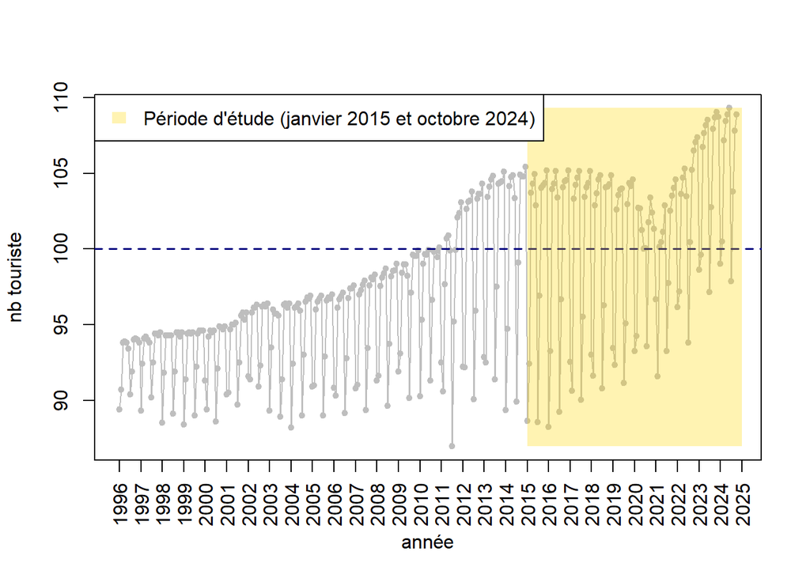

```r
plot(Ind_prix.ts , # la série à représenter
     col="gray", # couleur de la courbe
     ylab= "nb touriste",
     xlab= "année",
     xaxt = "n"  # Désactive l'affichage automatique de l'axe des x
)

# Ajouter les points aux observations
points(Ind_prix.ts , # la série à représenter
       col="grey", # couleur des points
       pch=20 # type de points
)

## Ajout de la ligne horizontale à l'indice 100
ligne_100 = abline(h=100,
       col= rgb(0, 0, 0.5),
       lty=2,
       lwd = 1.5)

## Ajout du rectangle entre janvier 2015 et octobre 2024 pour montrer la pérode sur laquelle on va porter notre analyse

rect(xleft = 2015, xright = 2025, ybottom = min(Ind_prix.ts), ytop = max(Ind_prix.ts), col = rgb(1, 0.84, 0, alpha = 0.3),border = NA)

legend("topleft",
       legend = "Période d'étude (janvier 2015 et octobre 2024)",
       fill = rgb(1, 0.84, 0, alpha = 0.3),
       border = NA)

# Ajouter les étiquettes sur l'axe des x (en années), en prenant un intervalle d'un an
axis(1, at = seq(1996, 2025, by = 1), labels = seq(1996, 2025, by = 1), las = 2)
```

```r
ind15 = window(Ind_prix.ts, start = c(2015, 01), frequency = 12)
```

## Modèle de la serie temporelle

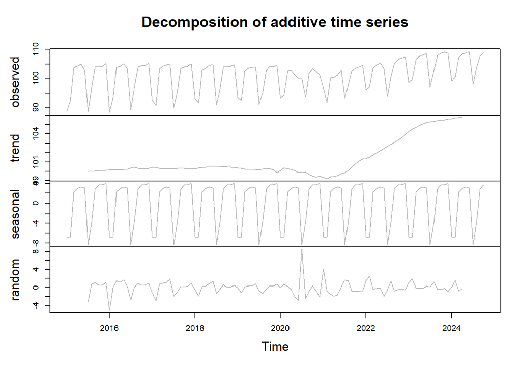

```r
decomposition <- decompose(ind15)
plot(decomposition,col = "grey")
```

# La tendance

## Ajustement par l’exponentielle

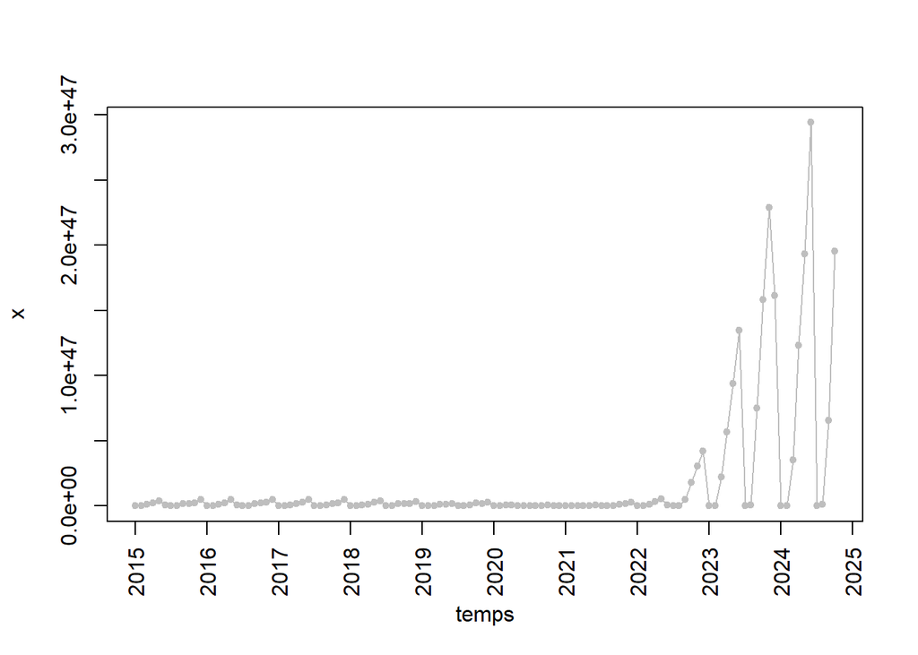

```r
t = 1:12
serie_exp = exp(ind15) # on passe la serie a l'exponentielle

x= plot (serie_exp, xlab = "temps", ylab = "x", xaxt = "n",col = "grey") #visualisation

points(serie_exp,
       col="grey", # couleur des points
       pch=20)

# Ajouter les étiquettes sur l'axe des x (en années), en prenant un intervalle d'un an
axis(1, at = seq(2015, 2025, by = 1), labels = seq(2015, 2025, by = 1), las = 2)
```

Ici on voit qu’en passant la série à l’exponentielle aucune tendance linéaire apparaît donc on sait que l’ajustement par l’exponentielle n’est pas nécessaire. C’est pourquoi nous allons essayer avec un ajustement non-paramétrique.

## Ajustement non-paramétrique

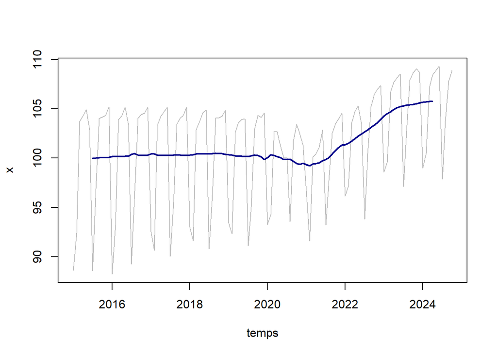

```r
#Moyenne mobile de rang 12
p =12
MM4 = stats::filter(x = ind15,  #filtre de moyenne mobile
             filter = c(1/(2*p), # Poids de la première valeur (1 / (2 * p))
                        rep(1/p,p-1), #Poids des valeurs centrées (égaux)
                        1/(2*p)) # Poids de la dernière valeur (1 / (2 * p))
)
MM4=round(MM4,2) #arrondir les moyennes mobiles

x= plot (ind15, xlab = "temps", ylab = "x",col = "grey")

lines(MM4, col = "darkblue",lwd = 2)
```

## Ajustement linéaire

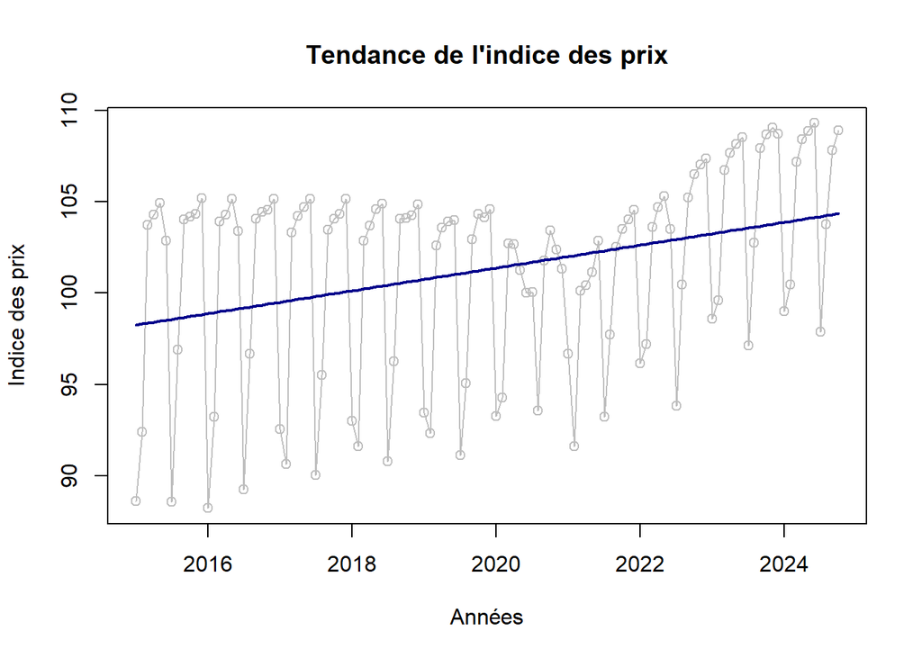

```r
T = length(ind15) #longueur série temporelle
t = 1:T
ajust_tend_x = lm(ind15 ~ t)# Ajustement d'un modèle de régression linéaire pour la tendance (moindres carrés)

ajust_tend_x.ts = ts(ajust_tend_x$fitted.values,start=c(2015,1), freq=12) # ajustmeent sous forme d'une série temporelle

# Créer le graphique de base
plot(ind15,
     xlab = "Années",
     ylab = "Indice des prix",
     type = "o",
     col = "grey",
     main = "Tendance de l'indice des prix")

# Ajouter la ligne de tendance en utilisant les valeurs ajustées du modèle
lines(ajust_tend_x.ts, col = "darkblue", lwd = 2)
```

# Visualisations des deux tendances de notre série

Cependant on distingue deux tendances “différentes” dans ind15. De 2015 a début 202, on a une tendance qui croît mais très lentement alors qu’à partir de mars 2020 la tendance croît beaucoup plus rapidement. On visualise ces deux périodes distinctes ci-dessous.

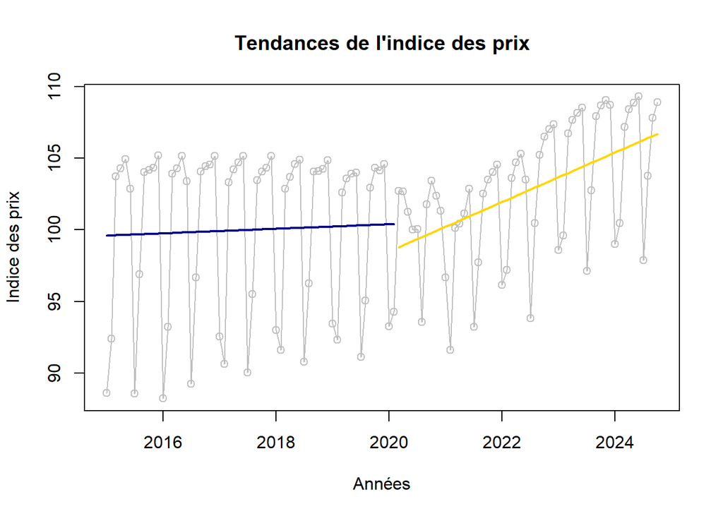

```r
#on divise en deux periode (avant covid/pendant et après)
a = window(ind15,end = c(2020,02))
b = window(ind15,start = c(2020,03))

Ta = length(a)
ta = 1:Ta
ajust_tend_xa = lm(a ~ ta)

ajust_tend_xa.ts = ts(ajust_tend_xa$fitted.values,end = c(2020,02), freq=12)

Tb = length(b)
tb = 1:Tb
ajust_tend_xb = lm(b ~ tb)

ajust_tend_xb.ts = ts(ajust_tend_xb$fitted.values,start = c(2020,03), freq=12)

# Créer le graphique de base
plot(ind15,
     xlab = "Années",
     ylab = "Indice des prix",
     type = "o",
     col = "grey",
     main = "Tendances de l'indice des prix")

# Ajouter la ligne de tendance en utilisant les valeurs ajustées du modèle
lines(ajust_tend_xa.ts, col = "darkblue", lwd = 2)
lines(ajust_tend_xb.ts, col = "gold", lwd = 2)
```

# Saisonnalité

## Paramétrique

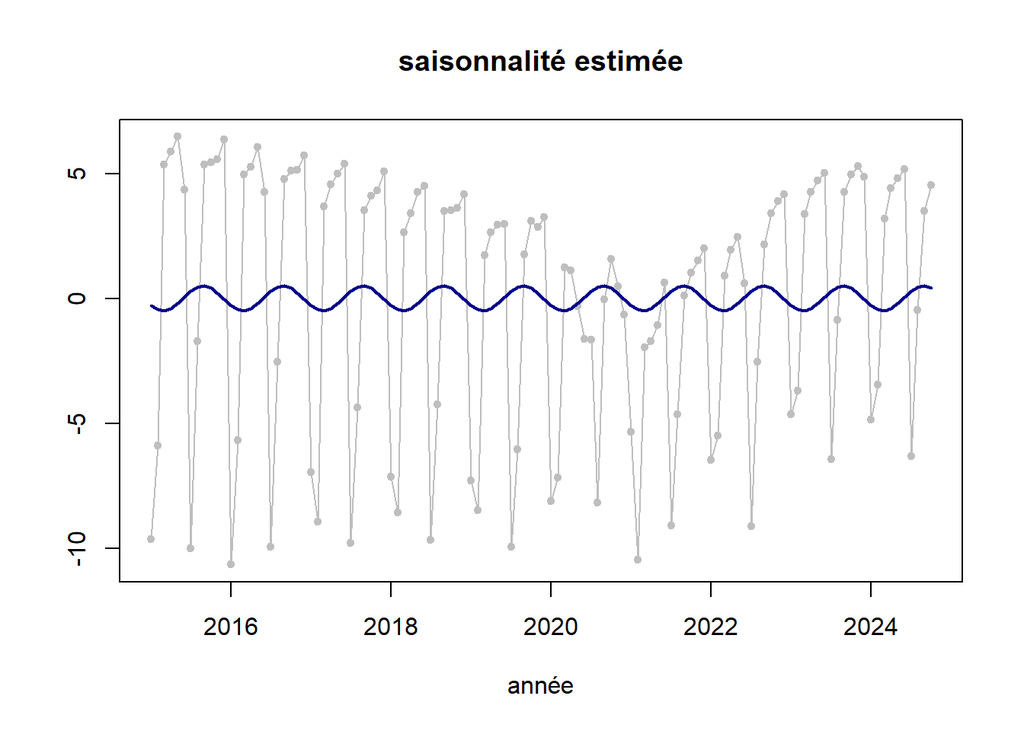

```r
ind_sans_tend1 = ind15-ajust_tend_x$fitted.values #on enlève la tendance pour se concentrer sur la saisonnalité


# Nombre d'observations
T = length(ind15)
t = 1:T
# Saison de 12 mois
s = 12


sint = sin(2 * pi * t/ s)
cost = cos(2 * pi * t / s)


ajust = lm(ind_sans_tend1~cost+sint) # calcul des paramètres estimés en fonction de sint et cost

ajust.ts = ts(ajust$fit, #(fitted values les estimations pour chaque mois et chaque année)
              start = c(2015,01),
              frequency = 12)
plot(ind_sans_tend1,xlab = "année",ylab="", main = "saisonnalité estimée", type = "o", pch = 20, col = "grey")
lines(ajust.ts,col = "darkblue", lwd = 2)
```

## Non-paramétrique

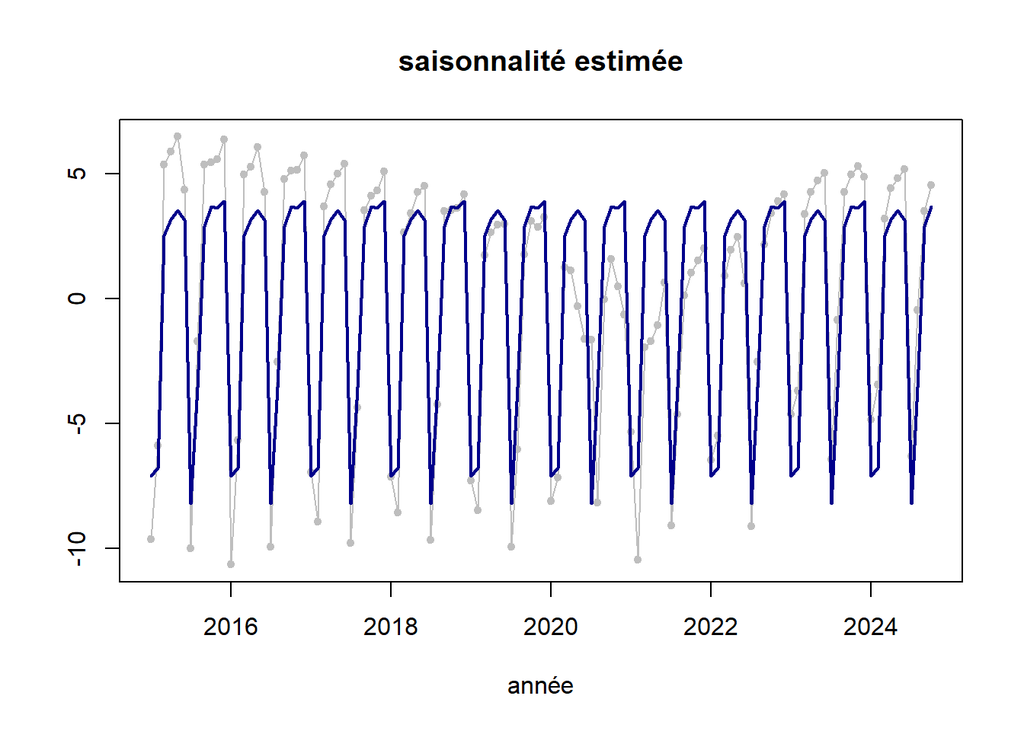

```r
moy_sais= aggregate(ind_sans_tend1~cycle(ind15), FUN=mean) #Trouver le motif saisonnier

S=12
d = length(ind15)
ind_sais=rep(moy_sais$ind_sans_tend,length.out = d) # répetition du motif pour chaque année
ind_sais=ts(ind_sais, start=2015, freq=12)

plot(ind_sans_tend1,xlab = "année",ylab="", main = "saisonnalité estimée", type = "o", pch = 20, col = "grey")
lines(ind_sais, lwd = 2, col = "darkblue")
```

On choisit donc la saisonnalité non-paramétrique

# Prévision sans Covid

## Création des séries pour les périodes

```r
ind_avant_sc <- window(ind15, end = c(2019, 12), frequency = 12)
ind_apres_sc <- window(ind15, start = c(2020, 1), frequency = 12)
```

### Ajustement de la tendance linéaire

```r
# Temps pour la période d'observation
T2 <- length(ind_avant_sc )
t <- 1:T2


ajust_tend1 <- lm(ind_avant_sc  ~ t)
pred_tend_avant <- ajust_tend1$fitted.values
```

### Ajustement de la saisonnalité

```r
ind_sans_tend1 = ind_avant_sc -ajust_tend1$fitted.values

moy_sais= aggregate(ind_sans_tend1~cycle(ind_avant_sc ), FUN=mean) #Trouver le motif saisonnier
```

## Prévision de la tendance

```r
# période de prévision
N2 <- length(ind_apres_sc )   # Nombre de périodes après 2020
n <- (T2 + 1):(T2 + N2)   # Temps pour les prévisions

nd_tend <- data.frame(t = n) #tableau de la taille de n
pred_tend_apres <- predict(ajust_tend1, newdata = nd_tend) # prévisions de tendance
```

## Prévision de la saisonnalité

```r
#Prévision saisonnalité non parametrique
S=12

ind_sais=rep(moy_sais$ind_sans_tend1,length.out = N2)

ind_sais=ts(ind_sais, start=2020, freq=12)
```

## Prévison Paramétrique de la série

```r
predserie <- ts(pred_tend_apres + ind_sais, start = c(2020, 1), frequency = 12) #prevision de la série en fonction des prévisions de la tendances et celles de la saisonnalité
```

## Visualisation

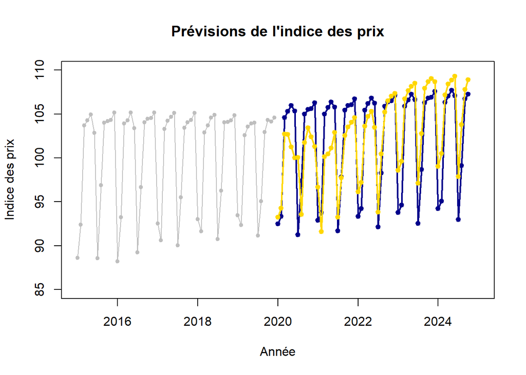

```r
plot(ind_avant_sc, xlab = "Année", ylab = "Indice des prix", col = "grey",
     xlim = c(2015, 2025), ylim = c(85,110),
     type = 'o', pch = 20, main = "Prévisions de l'indice des prix")

# Ajout des observations avant 2020
lines(ind_avant_sc, col = "grey", type = "o", pch = 20)

# Ajout des prévisions après 2020
lines(predserie, col = "darkblue", type = "o", pch = 20, lwd = 2)

# Ajout de la réalité
lines(ind_apres_sc, col = "gold", type = "o", pch = 20, lwd = 2)
```

## Erreur quadratique moyenne du modèle

```r
eqm_sans_cov <- sqrt(mean((ind_apres_sc - predserie)^2)) #formule de l'erreur quadratique moyenne
print(eqm_sans_cov )
```

```
## [1] 3.197023
```

## Visualisation résidus prévision sans covid

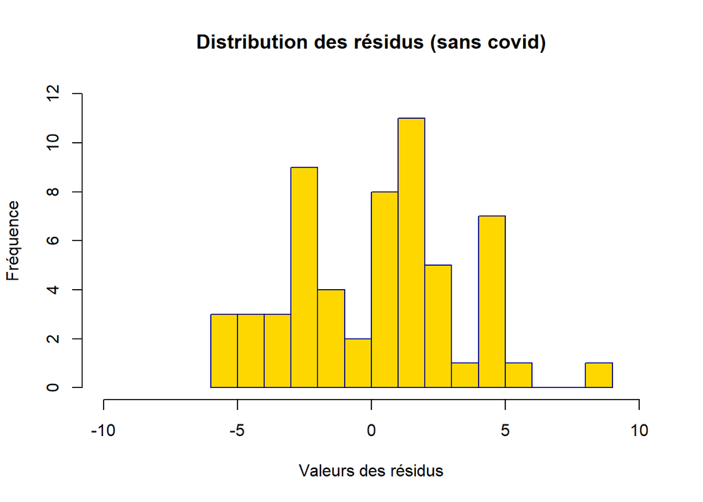

```r
res2 <- ind_apres_sc - predserie # on sustrait nos valeurs observé et celles estimées


hist(res2, breaks = 20,col = "gold", border = "darkblue", main = "Distribution des résidus (sans covid)",
     xlab = "Valeurs des résidus", ylab = "Fréquence", xlim = c(-10,10), ylim = c(0,12))
```